# Final Project STAT184

Milo Schmitt, Matt Viana

2023-12-05

# Determining indicators of win percentage in League of Legends

### Abstract:

League of Legends, normally referred to as LoL, stands as one of the most popular and competitive Multiplayer Online Battle Arena (MOBA) games globally. Its main draw is its fast-paced and strategic competitive nature. Players aim to win at any cost, a small lead can place you in an advantageous position to take control of the game. As a statistical analyst delving into the data-heavy world of LoL, this project aims to unravel the dynamics and nuances within ranked games to determine the highest indicators of win percentage.

The focus of this analysis was on exploring 116,046 matches between two distinct servers: the Brazilian Server for season 13 containing 64,556 matches and the High Elo tiers (top 1% of players) on the Western European Server in season 9 containing 51,490 matches. Every in-game season brings with it large updates to the game that create variations in strategies and playstyles. Additionally, variations between a large number of seasons have a compounding effect. Moreover, different servers have distinct cultures reflecting their real-world bias. Even though strategies might change, the in-game objectives largely stay the same. The theory behind this analysis comes from the idea that by analyzing the win percentage based on constant objectives through wildly different seasons, servers, and ranks, we can determine universal victory indicators.

By scrutinizing comprehensive datasets and employing robust statistical methodologies using R programming, this research endeavors to shed light on patterns that enable victory. Understanding these intricate aspects not only advances our comprehension of player behaviors but also contributes significantly to developing strategies and the landscape of competitive gaming analysis.

### Recognizing the Criteria:

An important note before we begin is that LoL is a nuanced game, and teams have won games despite insurmountable odds. We will begin by discussing general terminology and objectives.

In its simplest form, League of Legends is a five versus five objective-capturing game, the team that captures the adversary’s base (Nexus) wins. Matches are usually around 30 minutes long. Each player is represented by one Champion who increases in power as the game goes on by leveling up with experience points and buying in-game items with gold. Though capturing the Nexus is the final goal there are five other capturable objectives, consisting of two structure objectives, Towers, and Inhibitors, and three monster objectives, Drakes, Rift Heralds, and Barons. Moreover, objectives are only available on the map at a specific time. They are accessible to both teams at the same time providing gold and experience points as a reward at capture. Additionally, they also provide a special in-game bonus, ranging from basic upgrades to character attributes, all the way to deployable siege weapons.

With this information in mind, we decided to analyze five in-game attributes:

- First Blood: The first team to eliminate a champion from the other team.
- Victorious Side: Each team is assigned an opposite side of the map to defend. Blue or Red.
- Amount of Drakes Captured: Amount of Drake objectives captured by each team.
- Amount of Rift Heralds Captured: Amount of Rift Herald’s objectives captured by each team.
- Amount of Barons Captured: Amount of Baron objectives captured by each team.

### Surveying the Data:

An obvious starting point was to determine if there are differences in win rate based on in-game geographical differences. In other words, are both side’s win rates(Red or Top Side, and Blue or Bottom Side) equal?

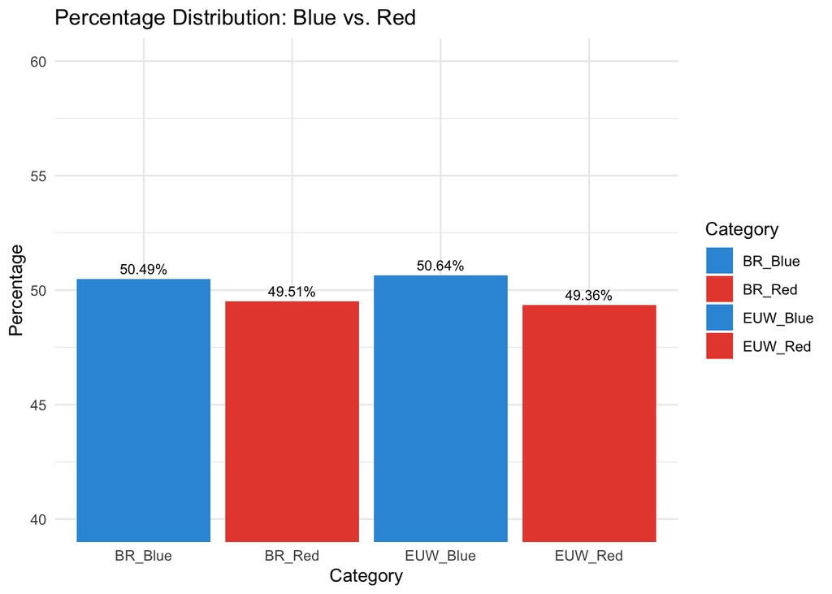

By creating a simple bar plot and limiting the Y axis between 40% and 60%, two consistencies between the data sets are on display. Firstly, the difference between both teams is as close to zero as a player could ever demand in a dynamic and competitive game. Secondly, the Blue Team consistently has the slightest of upper hands.

On the note of in-game geography, the second metric to verify is if there are any advantages to objective capture rates based on a team’s location. Due to the map being mirrored on both sides, the Red Team should have easier access to Drake objectives, while the Blue Side should have easier access to Baron and Rift Herald objectives (Baron and Rift Herald are in the same location).

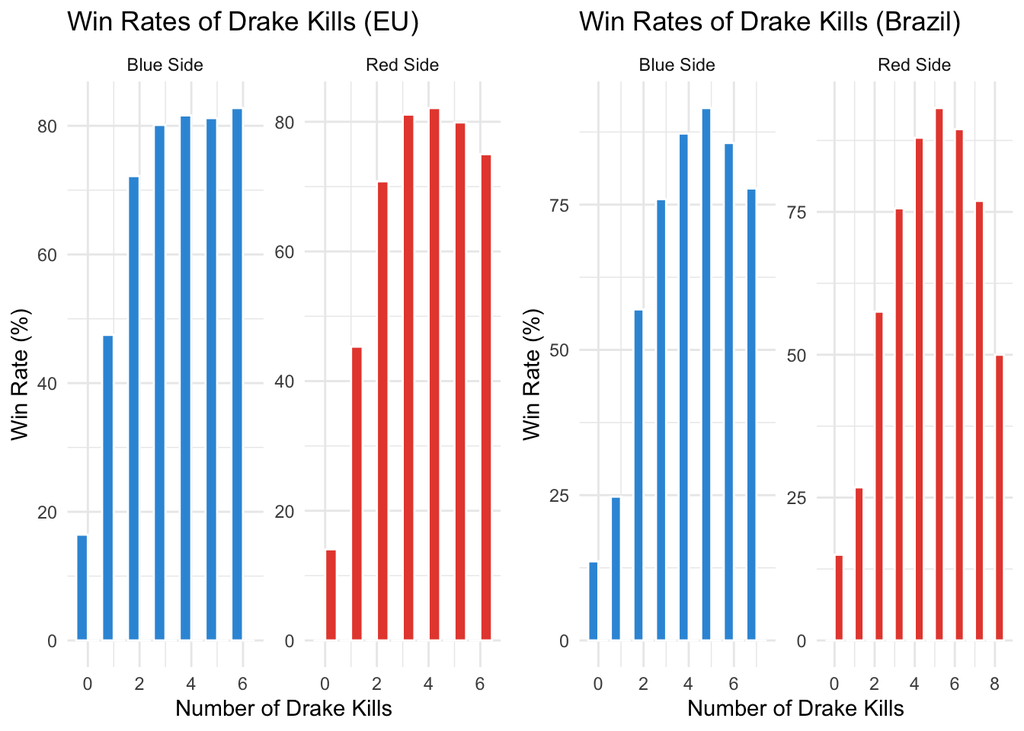

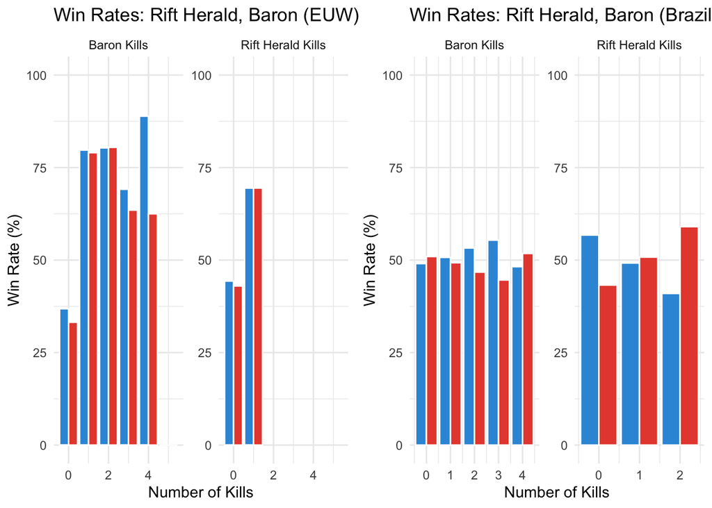

Average Win Rates for Baron Kills in Brazil

| kills | avg_win_rate_blue | avg_win_rate_red |
| --- | --- | --- |
| 0 | 49.04696 | 50.95304 |
| 1 | 50.72003 | 49.27997 |
| 2 | 53.25387 | 46.74613 |
| 3 | 55.38329 | 44.61671 |
| 4 | 48.21429 | 51.78571 |

As a student, analyst, and player, the results of this data have a direct effect on me. Part of the draw of researching a topic I am passionate about is the possibility of being surprised. With that said, I never expected these results.

Oddly, the Herald win percentage differences are significant for each team in the Brazilian servers. When no team captures Herald, the Blue Team has a large advantage, additionally, the Red Team has an even greater chance at victory if they capture both Heralds than the Blue Team does if they capture it. Finally, the data I was shocked about and the reason I decided to only tabulate Baron win rates, specifically for the Brazilian servers, is that there is no reliable numeric advantage for capturing a Baron. Though it might be tempting to label them as regional differences, I am more inclined to attribute this to player rank. The European data accounted for a small percentage of the player base in that region, whereas the Brazilian data measured over 90% of players. Individuals who are less knowledgeable on their approach to taking advantage of the game-defining benefits of Baron.

It seems to be that every objective is worth its weight in gold for skilled players, and the coordination and carefulness required for the capture greatly affect its value for lower-ranked players.

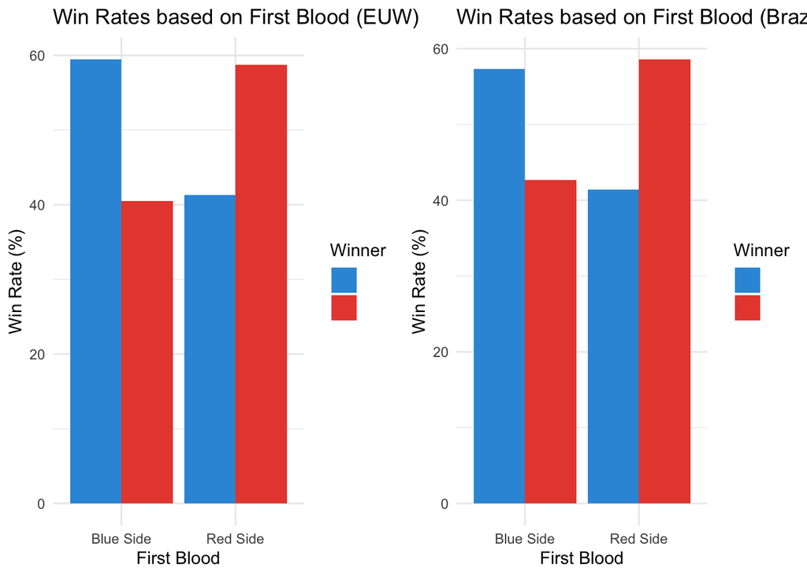

Win Rates based on First Blood (EUW) Note: Blue Team is team 1

| firstBlood | count | 1 | 2 |
| --- | --- | --- | --- |
| 1 | 10581 | NA | 40.52005 |
| 1 | 15532 | 59.47995 | NA |
| 2 | 10247 | 41.28193 | NA |
| 2 | 14575 | NA | 58.71807 |

Win Rates based on First Blood (Brazil) Note: Blue Team is team 1

| blueFirstBlood | count | False | True |
| --- | --- | --- | --- |
| False | 14014 | NA | 42.66447 |
| False | 18833 | 57.33553 | NA |
| True | 13128 | 41.40149 | NA |
| True | 18581 | NA | 58.59851 |

The last metric measured was the First Blood. Defined as the first elimination for a match, the player responsible gains a bonus 33% gold reward when compared to later eliminations, which leads to early advantages in power and team morale. This data point most clearly indicates a consistent and statistically significant increase in win rate at nearly 60% regardless of team, server, or skill level.

### Conclusion:

The investigation into League of Legends (LoL) aimed to decipher the critical factors dictating victory in this highly competitive multiplayer online battle arena (MOBA) game. Analyzing over 116,000 matches from both the Brazilian and Western European servers across different seasons and player ranks, the study homed in on specific in-game metrics to unveil universal indicators of success. Despite the ever-evolving strategies and game updates with each new season, key objectives like First Blood, team sides, and objective captures remained constant. This study sought to illuminate these constants across diverse seasons, servers, and player ranks to uncover their role as fundamental drivers of victory.

### Works Cited:

________________________________________________________________________________________________________________

Junior, Jailson Barros da Silva, and Claudio Campelo. “League of Legends Match Data at Various Time Intervals.” *Zenodo*, Zenodo, 31 Aug. 2023, zenodo.org/records/8303397.

“League of Legends Wiki.” *Fandom*, leagueoflegends.fandom.com/wiki/League_of_Legends_Wiki. Accessed 13 Dec. 2023.

Roopnaire, Kristian. “ML-League-Of-Legends.” *GitHub*, github.com/Kristian-Roopnarine/ML-League-Of- Legends/blob/master/games.csv. Accessed 13 Dec. 2023.